# When and Why Advice-Taking Strategies Differ:

A Dual-Hurdle-Based Meta-Analysis

Jessica Helmer | TeaP | 2026-03-16

## Advice-Taking

Studies on advice taking often use a Judge Advisor System setup

○ Judge makes initial judgement

○ Judge receives advice

○ Judge makes final judgement

Outcome metric commonly “Weight of Advice” (WOA)

$$WOA = \frac{\text{initial} - \text{final}}{\text{initial} - \text{advice}}$$

| \(WOA = 0\) | Decline |
| --- | --- |
| \(WOA = 1\) | Adopt |
| \(0 < WOA < 1\) | Compromise |

## Weight of Advice

WOA continuous metric, but often empirically see concentrations of values at 0 and 1

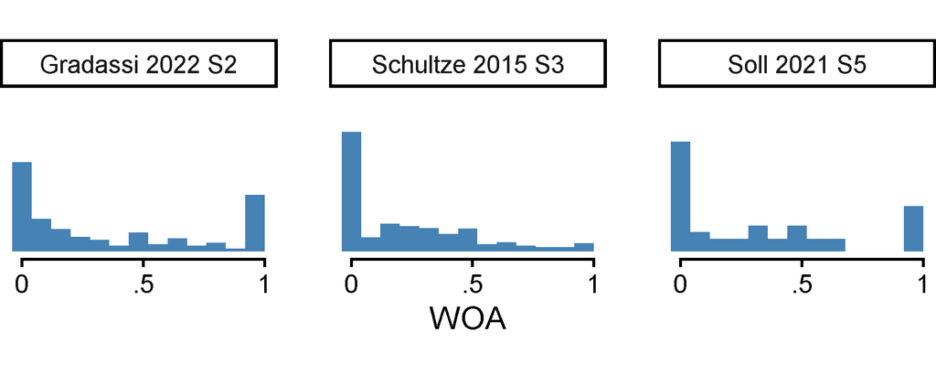

Typically are modeled with standard linear regression procedures

○ Assume normally distributed residuals!

(Himmelstein, 2022)

## Dual-Hurdle Model

Separates outcome into two phases:

**Discrete**

Decline, adopt, or compromise?

Categorical logit: estimates probability of each choice

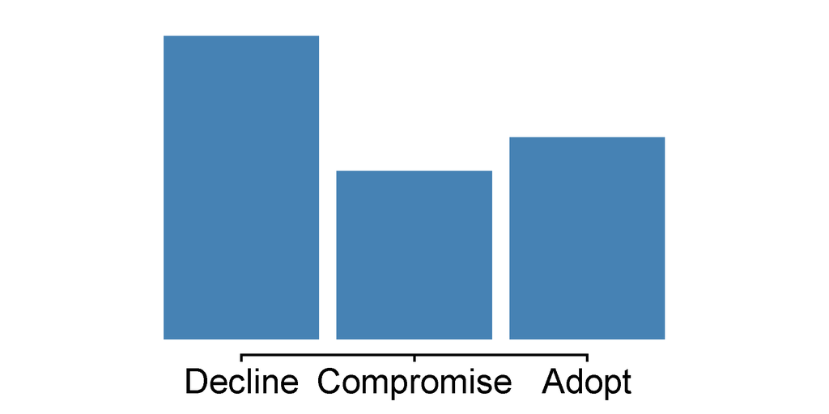

**Continuous**

If compromise, how much?

Beta distribution: estimates continuous WOA between 0 and 1

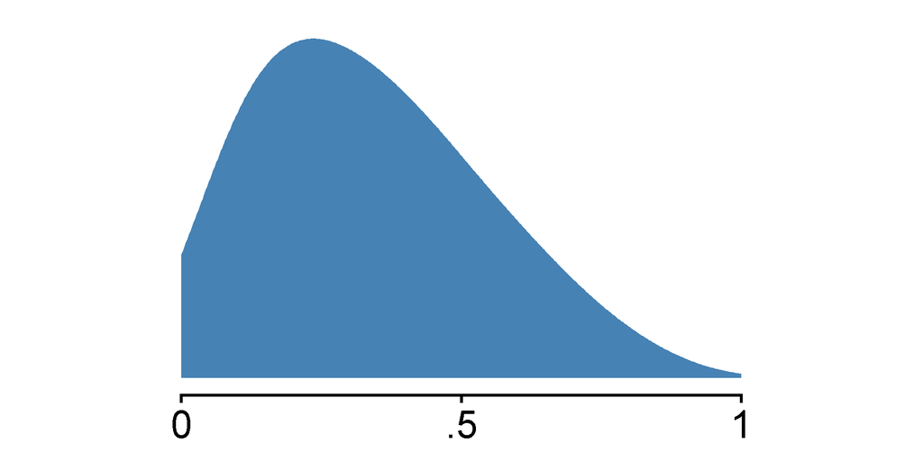

(Himmelstein, 2022)

## Dual-Hurdle Model

Makes WOA distributions like…

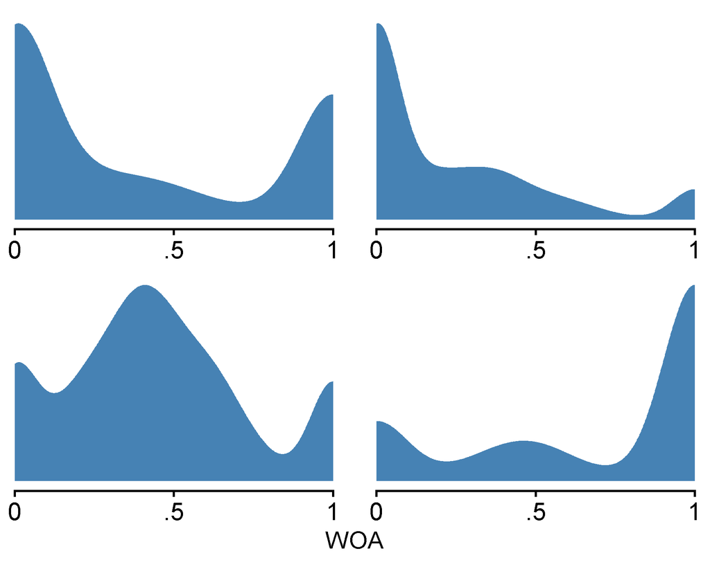

Can examine effects of predictors for both the categorical and continuous pieces

Captures variation at the item- and person-level

Present study: extend dual-hurdle model to meta-analytic context

○ Account for study-level variation

(Himmelstein, 2022)

## Present Study

Used data collected for an advice-taking metaanalysis on gender effects (Kausel et al., 2024)

○ Full dataset included 94 studies and 308,230 observations.

Removed cases that had missing data for WOA or any of the predictors

Predictors

| Trial-Level | Person-Level | Study-Level |
| --- | --- | --- |
| ○ Advice Distance ○ Confidence | ○ Age ○ Gender | ○ Student Population ○ Almanac Item ○ Future Item ○ Expert Advisor ○ Incentive |

(Kausel et al., 2024)

## Dual-Hurdle Model

Distribution of WOA values as per the **data** and the model predictions

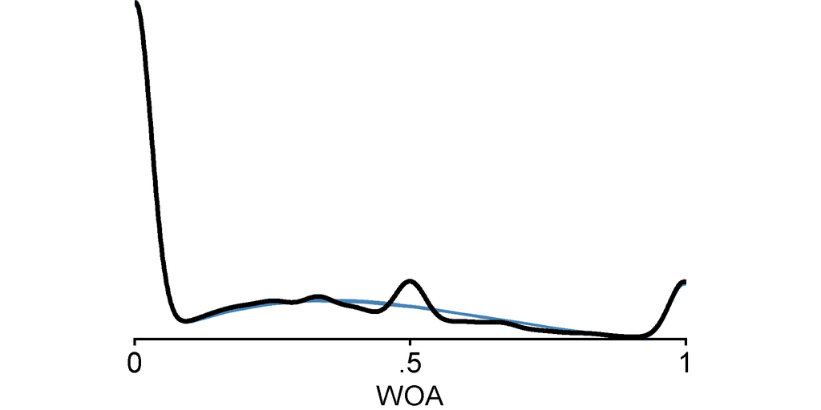

## Dual-Hurdle Model

Distribution of WOA values as per the **data** and the model predictions

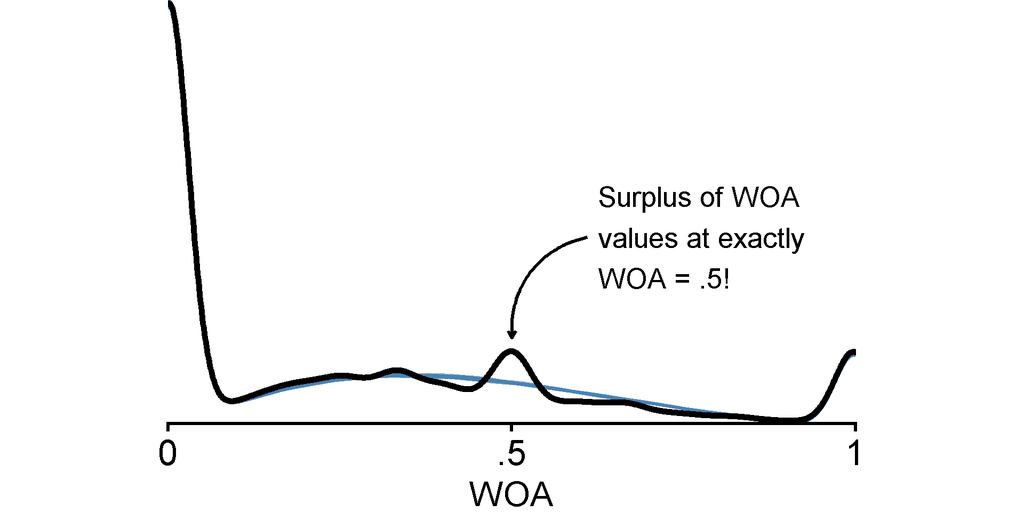

## Tri-Hurdle Model

Added a categorical choice: Decline, Adopt, **Midpoint**, Compromise

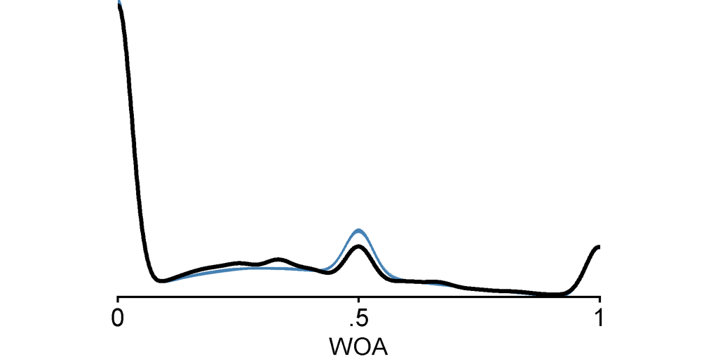

## Tri-Hurdle Model

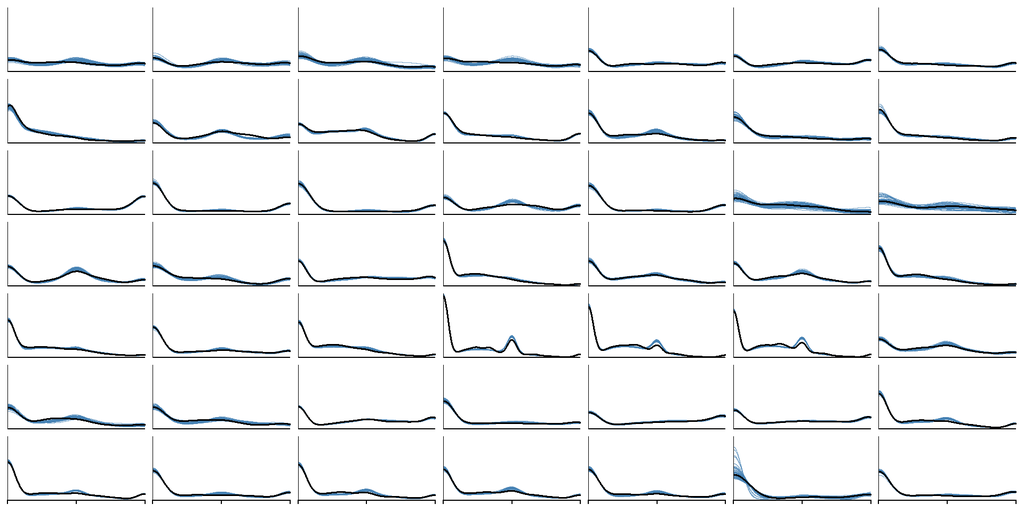

## Decline, Adopt, Midpoint, Compromise

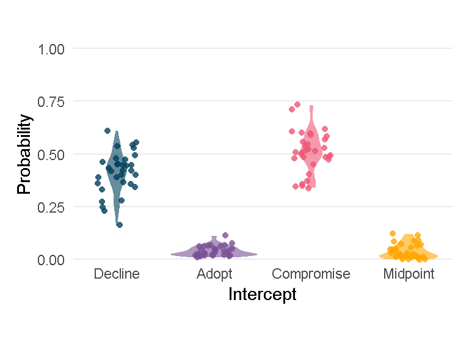

## Distance and Confidence

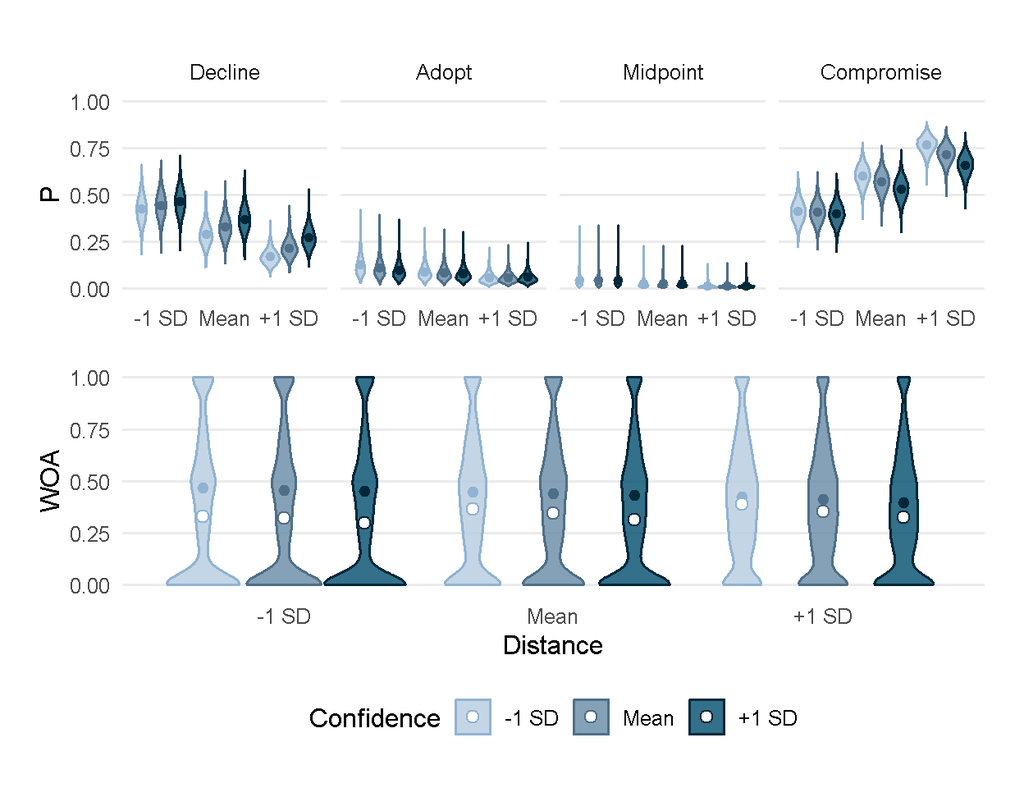

## Age and Gender

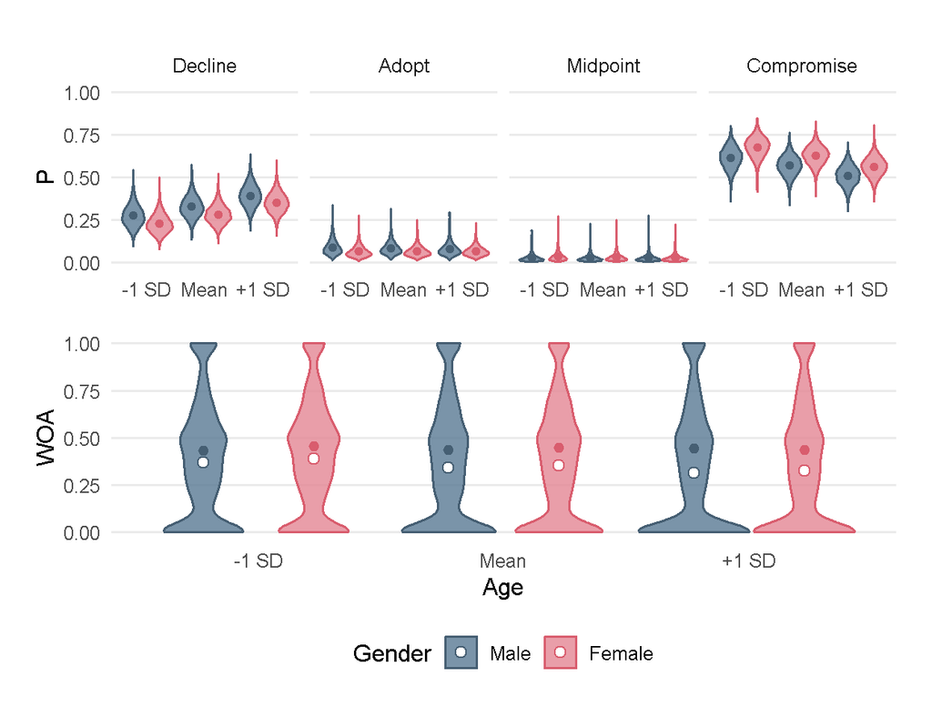

## Study-Level Predictors

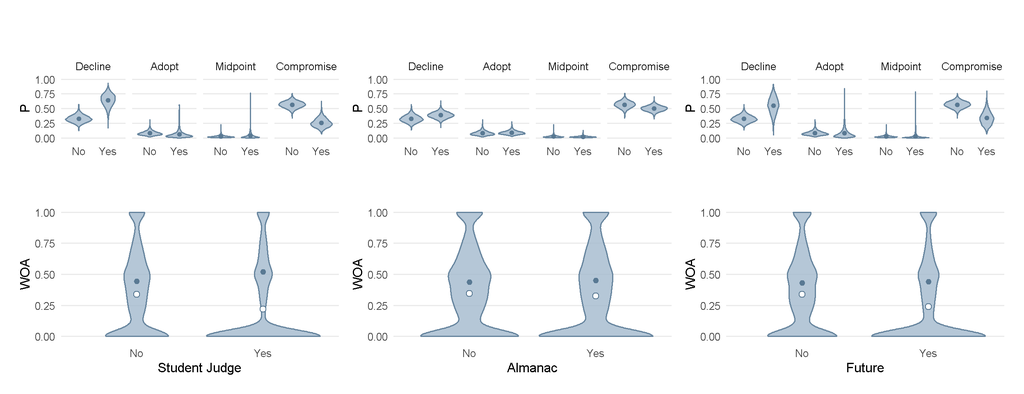

## Study-Level Predictors

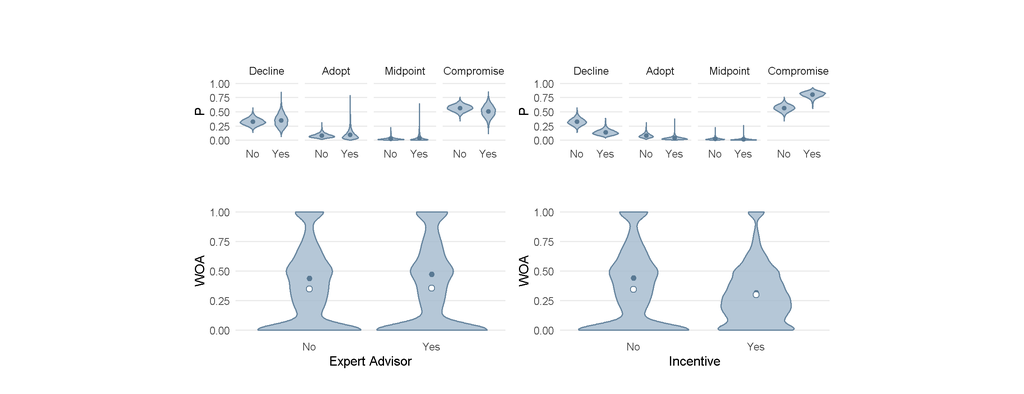

## Discussion

Midpoint averaging common, could be relevant to include in model

○ Varies by study

Differences between student and non-student populations

○ Declining a lot, but updating more when compromise

Differences between incentivised and non-incentivised studies

## References

Kausel, E.E., Ventura, S., Reyes, V. (November 2024). [Conference presentation]. Gender Differences in Advice Taking: A Meta-Analytic Path Model. Society of Judgement and Decision Making, New York, NY.

Himmelstein, M. (2022). Decline, adopt or compromise? A dual hurdle model for advice utilization. Journal of Mathematical Psychology, 110, 102695. https://doi.org/10.1016/j.jmp.2022.102695

# Thank You!

Contact: jhelmer3@gatech.edu

[figure not shown]